# Project Two: Logistic Regression and Random Forests

For Project Two, you have been asked to create different models analyzing a Heart Disease data set. Before beginning work on the project, be sure to read through the Project Two Guidelines and Rubric to understand what you need to do and how you will be graded on this assignment. Be sure to carefully review the Project Two Summary Report template, which contains all of the questions that you will need to answer about the regression analyses you are performing.

For this project, you will be writing all the scripts yourself. You may reference the textbook and your previous work on the problem sets to help you write the scripts.

### Scenario

You are a data analyst researching risk factors for heart disease at a university hospital. You have access to a large set of historical data that you can use to analyze patterns between different health indicators (e.g. fasting blood sugar, maximum heart rate, etc.) and the presence of heart disease. You have been asked to create different logistic regression models that predict whether or not a person is at risk for heart disease. A model like this could eventually be used to evaluate medical records and look for risks that might not be obvious to human doctors. You have also been asked to create a classification random forest model to predict the risk of heart disease and a regression random forest model to predict the maximum heart rate achieved.

There are several variables in this data set, but you will be working with the following important variables:

| Variable | What does it represent? |
| --- | --- |
| age | The person's age in years |
| sex | The person's sex (1 = male, 0 = female) |
| cp | The type of chest pain experienced (0=no pain, 1=typical angina, 2=atypical angina, 3=non-anginal pain) |
| trestbps | The person's resting blood pressure |
| chol | The person's cholesterol measurement in mg/dl |
| fbs | The person's fasting blood sugar is greater than 120 mg/dl (1 = true, 0 = false) |
| restecg | Resting electrocardiographic measurement (0=normal, 1=having ST-T wave abnormality, 2=showing probable or definite left ventricular hypertrophy by Estes' criteria) |
| thalach | The person's maximum heart rate achieved |
| exang | Exercise-induced angina (1=yes, 0=no) |
| oldpeak | ST depression induced by exercise relative to rest ('ST' relates to positions on the ECG plot) |
| slope | The slope of the peak exercise ST segment (1=upsloping, 2=flat, 3=downsloping) |
| ca | The number of major vessels (0-3) |
| target | Heart disease (0=no, 1=yes) |

## Install Libraries

In the following code block, you will install appropriate libraries to use in this project.

Click the **Run** button on the toolbar to run this code.

```r
install.packages("ResourceSelection")
install.packages("pROC")
install.packages("rpart.plot")
```

## Prepare Your Data Set

In the following code block, you have been given the R code to prepare your data set.

Click the **Run** button on the toolbar to run this code.

```r
heart_data <- read.csv(file="heart_disease.csv", header=TRUE, sep=",")

# Converting appropriate variables to factors
heart_data <- within(heart_data, {
   target <- factor(target)
   sex <- factor(sex)
   cp <- factor(cp)
   fbs <- factor(fbs)
   restecg <- factor(restecg)
   exang <- factor(exang)
   slope <- factor(slope)
   ca <- factor(ca)
   thal <- factor(thal)
})

head(heart_data, 10)

print("Number of variables")
ncol(heart_data)

print("Number of rows")
nrow(heart_data)
```

A data.frame: 10 × 14

| age <int> | sex <fct> | cp <fct> | trestbps <int> | chol <int> | fbs <fct> | restecg <fct> | thalach <int> | exang <fct> | oldpeak <dbl> | slope <fct> | ca <fct> | thal <fct> | target <fct> |
| --- | --- | --- | --- | --- | --- | --- | --- | --- | --- | --- | --- | --- | --- |
| 62 | 1 | 2 | 130 | 231 | 0 | 1 | 146 | 0 | 1.8 | 1 | 3 | 3 | 1 |
| 58 | 0 | 0 | 130 | 197 | 0 | 1 | 131 | 0 | 0.6 | 1 | 0 | 2 | 1 |
| 60 | 0 | 3 | 150 | 240 | 0 | 1 | 171 | 0 | 0.9 | 2 | 0 | 2 | 1 |
| 63 | 1 | 0 | 140 | 187 | 0 | 0 | 144 | 1 | 4.0 | 2 | 2 | 3 | 0 |
| 62 | 1 | 0 | 120 | 267 | 0 | 1 | 99 | 1 | 1.8 | 1 | 2 | 3 | 0 |
| 63 | 0 | 2 | 135 | 252 | 0 | 0 | 172 | 0 | 0.0 | 2 | 0 | 2 | 1 |
| 43 | 1 | 0 | 150 | 247 | 0 | 1 | 171 | 0 | 1.5 | 2 | 0 | 2 | 1 |
| 42 | 1 | 2 | 120 | 240 | 1 | 1 | 194 | 0 | 0.8 | 0 | 0 | 3 | 1 |
| 59 | 1 | 2 | 126 | 218 | 1 | 1 | 134 | 0 | 2.2 | 1 | 1 | 1 | 0 |
| 48 | 1 | 0 | 124 | 274 | 0 | 0 | 166 | 0 | 0.5 | 1 | 0 | 3 | 0 |

```
[1] "Number of variables"
```

14

```
[1] "Number of rows"
```

303

## Model #1 - First Logistic Regression Model

You have been asked to create a logistic regression model for heart disease *(target)* using the variables age *(age)*, resting blood pressure *(trestbps)*, and maximum heart rate achieved *(thalach)*. Before writing any code, review Section 3 of the Summary Report template to see the questions you will be answering about your logistic regression model.

Run your scripts to get the outputs of your regression analysis. Then use the outputs to answer the questions in your summary report.

**Note: Use the + (plus) button to add new code blocks, if needed.**

```r
# Create the complete model
logit <- glm(target ~ age + trestbps + thalach, data = heart_data, family = "binomial")

summary(logit)
```

```
Call:
glm(formula = target ~ age + trestbps + thalach, family = "binomial",
    data = heart_data)

Deviance Residuals:
    Min       1Q   Median       3Q      Max
-2.0257  -1.0069   0.5688   0.9203   2.0476

Coefficients:
             Estimate Std. Error z value Pr(>|z|)
(Intercept) -3.576198   1.633928  -2.189   0.0286 *
age         -0.009424   0.016080  -0.586   0.5578
trestbps    -0.016019   0.007767  -2.063   0.0392 *
thalach      0.042697   0.006950   6.144 8.06e-10 ***
---
Signif. codes:  0 '***' 0.001 '**' 0.01 '*' 0.05 '.' 0.1 ' ' 1

(Dispersion parameter for binomial family taken to be 1)

    Null deviance: 417.64  on 302  degrees of freedom
Residual deviance: 353.28  on 299  degrees of freedom
AIC: 361.28

Number of Fisher Scoring iterations: 3
```

```r
library(ResourceSelection)


print("Hosmer-Lemeshow Goodness of Fit Test")
hl = hoslem.test(logit$y, fitted(logit), g=50)
hl
```

```
ResourceSelection 0.3-5 	 2019-07-22
```

```
[1] "Hosmer-Lemeshow Goodness of Fit Test"
```

```
	Hosmer and Lemeshow goodness of fit (GOF) test

data:  logit$y, fitted(logit)
X-squared = 41.978, df = 48, p-value = 0.7168
```

```r
# Predict having a heart disease or no heart disease for the data set using the model
heart_model_data <- heart_data[c('age', 'trestbps','thalach')]
pred <- predict(logit, newdata=heart_model_data, type='response')

# If the predicted probability of default is >=0.50 then predict having a heart disease (target='1'),
# otherwise predict no heart disease (target='0')
depvar_pred = as.factor(ifelse(pred >= 0.5, '1', '0'))

# This creates the confusion matrix
conf.matrix <- table(heart_data$target, depvar_pred)[c('0','1'),c('0','1')]
rownames(conf.matrix) <- paste("Actual", rownames(conf.matrix), sep = ": target=")
colnames(conf.matrix) <- paste("Prediction", colnames(conf.matrix), sep = ": target=")

# Print nicely formatted confusion matrix
print("Confusion Matrix")
format(conf.matrix,justify="centre",digit=2)
```

```
[1] "Confusion Matrix"
```

A matrix: 2 × 2 of type chr

|  | Prediction: target=0 | Prediction: target=1 |
| --- | --- | --- |
| Actual: target=0 | 83 | 55 |
| Actual: target=1 | 38 | 127 |

```
[1] "Area Under the Curve (AUC)"
```

0.7575

```
[1] "ROC Curve"
```

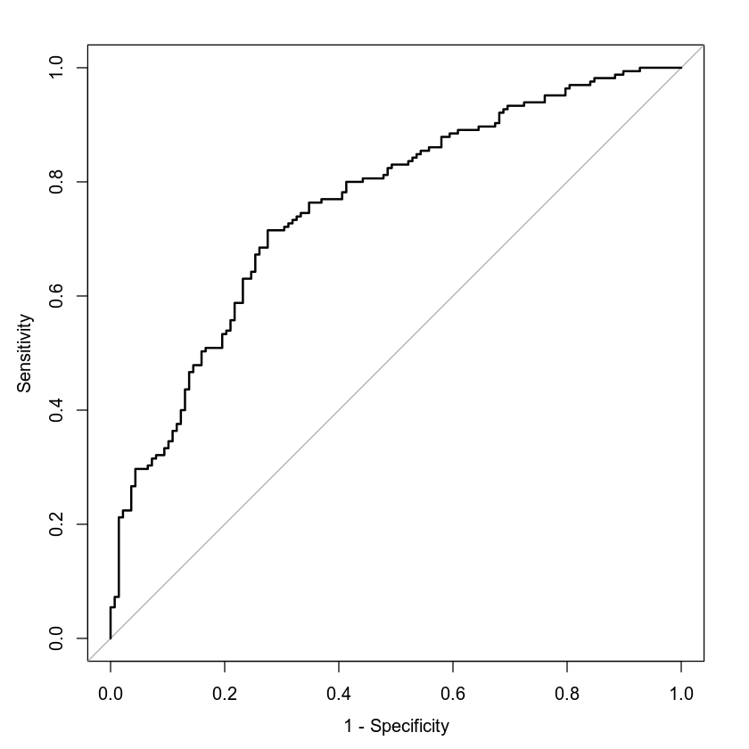

```r
library(pROC)

labels <- heart_data$target
predictions <- logit$fitted.values

roc <- roc(labels ~ predictions)

print("Area Under the Curve (AUC)")
round(auc(roc),4)

print("ROC Curve")
# True Positive Rate (Sensitivity) and False Positive Rate (1 - Specificity)
plot(roc, legacy.axes = TRUE)
```

```r
print("Prediction: age is 50 years (age=50), resting blood pressure is 112 (trestbps=112), maximum heart rate achieved is 140 (thalach=140)")
newdata1 <- data.frame(age=50, trestbps=112, thalach=140)
pred1 <- predict(logit, newdata1, type='response')
round(pred1, 4)

print("Prediction: age is 50 years (age=50), resting blood pressure is 140 (trestbps=140), maximum heart rate achieved is 170 (thalach=170)")
newdata2 <- data.frame(age=50, trestbps=140, thalach=170)
pred2 <- predict(logit, newdata2, type='response')
round(pred2, 4)
```

```
[1] "Prediction: age is 50 years (age=50), resting blood pressure is 112 (trestbps=112), maximum heart rate achieved is 140 (thalach=140)"
```

**1:** 0.5339

```
[1] "Prediction: age is 50 years (age=50), resting blood pressure is 140 (trestbps=140), maximum heart rate achieved is 170 (thalach=170)"
```

**1:** 0.7248

## Model #2 - Second Logistic Regression Model

You have been asked to create a logistic regression model for heart disease *(target)* using the variables maximum heart rate achieved *(thalach)*, age of the individual *(age)*, sex of the individual *(sex)*, exercise-induced angina *(exang)*, and type of chest pain *(cp)*. You also have to include the quadratic term for age and the interaction term between age and maximum heart rate achieved. Before writing any code, review Section 4 of the Summary Report template to see the questions you will be answering about your model.

Run your scripts to get the outputs of your analysis. Then use the outputs to answer the questions in your summary report.

**Note: Use the + (plus) button to add new code blocks, if needed.**

```r
# Create the complete model
logit <- glm(target ~ thalach + age + sex + exang + cp + I(age^2) + age:thalach, data = heart_data, family = "binomial")

summary(logit)
```

```
Call:
glm(formula = target ~ thalach + age + sex + exang + cp + I(age^2) +
    age:thalach, family = "binomial", data = heart_data)

Deviance Residuals:
    Min       1Q   Median       3Q      Max
-2.4225  -0.6167   0.2083   0.6646   2.5398

Coefficients:
              Estimate Std. Error z value Pr(>|z|)
(Intercept) -1.634e+01  1.205e+01  -1.356 0.175117
thalach      1.390e-01  5.701e-02   2.438 0.014760 *
age          2.049e-01  3.112e-01   0.658 0.510325
sex1        -1.709e+00  3.590e-01  -4.762 1.91e-06 ***
exang1      -9.348e-01  3.586e-01  -2.607 0.009133 **
cp1          1.766e+00  4.821e-01   3.663 0.000249 ***
cp2          1.820e+00  3.844e-01   4.734 2.21e-06 ***
cp3          1.674e+00  5.764e-01   2.904 0.003684 **
I(age^2)     4.921e-04  2.054e-03   0.240 0.810599
thalach:age -2.017e-03  9.999e-04  -2.017 0.043666 *
---
Signif. codes:  0 '***' 0.001 '**' 0.01 '*' 0.05 '.' 0.1 ' ' 1

(Dispersion parameter for binomial family taken to be 1)

    Null deviance: 417.64  on 302  degrees of freedom
Residual deviance: 263.42  on 293  degrees of freedom
AIC: 283.42

Number of Fisher Scoring iterations: 5
```

```r
library(ResourceSelection)


print("Hosmer-Lemeshow Goodness of Fit Test")
hl = hoslem.test(logit$y, fitted(logit), g=50)
hl
```

```
[1] "Hosmer-Lemeshow Goodness of Fit Test"
```

```
	Hosmer and Lemeshow goodness of fit (GOF) test

data:  logit$y, fitted(logit)
X-squared = 60.596, df = 48, p-value = 0.1048
```

```r
# Predict having a heart disease or no heart disease for the data set using the model
heart_model_data2 <- heart_data[c('thalach', 'age', 'sex', 'exang', 'cp')]
pred <- predict(logit, newdata=heart_model_data2, type='response')

# If the predicted probability of default is >=0.50 then predict having a heart disease (target='1'),
# otherwise predict no heart disease (target='0')
depvar_pred = as.factor(ifelse(pred >= 0.5, '1', '0'))

# This creates the confusion matrix
conf.matrix <- table(heart_data$target, depvar_pred)[c('0','1'),c('0','1')]
rownames(conf.matrix) <- paste("Actual", rownames(conf.matrix), sep = ": target=")
colnames(conf.matrix) <- paste("Prediction", colnames(conf.matrix), sep = ": target=")

# Print nicely formatted confusion matrix
print("Confusion Matrix")
format(conf.matrix,justify="centre",digit=2)
```

```
[1] "Confusion Matrix"
```

A matrix: 2 × 2 of type chr

|  | Prediction: target=0 | Prediction: target=1 |
| --- | --- | --- |
| Actual: target=0 | 103 | 35 |
| Actual: target=1 | 27 | 138 |

```
[1] "Area Under the Curve (AUC)"
```

0.8777

```
[1] "ROC Curve"
```

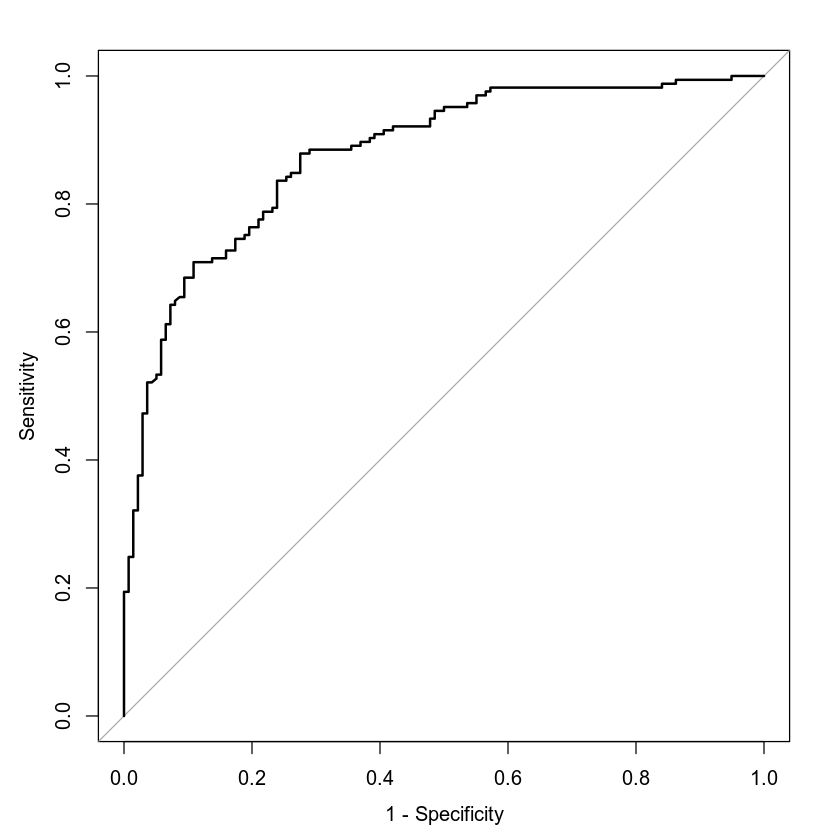

```r
library(pROC)

labels <- heart_data$target
predictions <- logit$fitted.values

roc <- roc(labels ~ predictions)

print("Area Under the Curve (AUC)")
round(auc(roc),4)

print("ROC Curve")
# True Positive Rate (Sensitivity) and False Positive Rate (1 - Specificity)
plot(roc, legacy.axes = TRUE)
```

```r
print("Prediction: male (sex='1'), age is 30 years (age=30), maximum heart rate achieved is 145 (thalach=140), experiences exercise-induced angia (exang='1'), no chest pain of any kind (cp='0')")
newdata1 <- data.frame(sex="1", age=30, thalach=145, exang="1", cp="0")
pred1 <- predict(logit, newdata1, type='response')
round(pred1, 4)

print("Prediction: male (sex='1'), age is 30 years (age=30), maximum heart rate achieved is 145 (thalach=140), does not experience exercise-induced angia (exang='0'), experiences typical angia (cp='1')")
newdata2 <- data.frame(sex="1", age=30, thalach=145, exang="0", cp="1")
pred2 <- predict(logit, newdata2, type='response')
round(pred2, 4)
```

```
[1] "Prediction: male (sex='1'), age is 30 years (age=30), maximum heart rate achieved is 145 (thalach=140), experiences exercise-induced angia (exang='1'), no chest pain of any kind (cp='0')"
```

**1:** 0.2654

```
[1] "Prediction: male (sex='1'), age is 30 years (age=30), maximum heart rate achieved is 145 (thalach=140), does not experience exercise-induced angia (exang='0'), experiences typical angia (cp='1')"
```

**1:** 0.8432

## Random Forest Classification Model

You have been asked to create a random forest classification model for the presence of heart disease *(target)* using the variables age *(age)*, sex *(sex)*, chest pain type *(cp)*, resting blood pressure *(trestbps)*, cholesterol measurement *(chol)*, resting electrocardiographic measurement *(restecg)*, exercise-induced angina *(exang)*, slope of peak exercise *(slope)*, and number of major vessels *(ca)*. Before writing any code, review Section 5 of the Summary Report template to see the questions you will be answering about your model.

Run your scripts to get the outputs of your regression analysis. Then use the outputs to answer the questions in your summary report.

**Note: Use the + (plus) button to add new code blocks, if needed.**

```r
set.seed(511038)

# Partition the data set into training and testing data
samp.size = floor(0.80*nrow(heart_data))

# Training set
print("Number of rows for the training set")
train_ind = sample(seq_len(nrow(heart_data)), size = samp.size)
train.data = heart_data[train_ind,]
nrow(train.data)

# Testing set
print("Number of rows for the testing set")
test.data = heart_data[-train_ind,]
nrow(test.data)
```

```
[1] "Number of rows for the training set"
```

242

```
[1] "Number of rows for the testing set"
```

61

```r
set.seed(511038)
library(randomForest)
model_rf2 <- randomForest(target ~ age + sex + cp + trestbps + chol + restecg + exang + slope + ca, data=train.data, ntree = 15)

# Confusion matrix
print("======================================================================================================================")
print('Confusion Matrix: TRAINING set based on random forest model built using 15 trees')
train.data.predict <- predict(model_rf2, train.data, type = "class")

# Construct the confusion matrix
conf.matrix <- table(train.data$target, train.data.predict)[,c('0','1')]
rownames(conf.matrix) <- paste("Actual", rownames(conf.matrix), sep = ": ")
colnames(conf.matrix) <- paste("Prediction", colnames(conf.matrix), sep = ": ")

# Print nicely formatted confusion matrix
format(conf.matrix,justify="centre",digit=2)


print("======================================================================================================================")
print('Confusion Matrix: TESTING set based on random forest model built using 15 trees')
test.data.predict <- predict(model_rf2, test.data, type = "class")

# Construct the confusion matrix
conf.matrix <- table(test.data$target, test.data.predict)[,c('0','1')]
rownames(conf.matrix) <- paste("Actual", rownames(conf.matrix), sep = ": ")
colnames(conf.matrix) <- paste("Prediction", colnames(conf.matrix), sep = ": ")

# Print nicely formatted confusion matrix
format(conf.matrix,justify="centre",digit=2)
```

```
[1] "======================================================================================================================"
[1] "Confusion Matrix: TRAINING set based on random forest model built using 15 trees"
```

A matrix: 2 × 2 of type chr

|  | Prediction: 0 | Prediction: 1 |
| --- | --- | --- |
| Actual: 0 | 111 | 1 |
| Actual: 1 | 1 | 129 |

```
[1] "======================================================================================================================"
[1] "Confusion Matrix: TESTING set based on random forest model built using 15 trees"
```

A matrix: 2 × 2 of type chr

|  | Prediction: 0 | Prediction: 1 |
| --- | --- | --- |
| Actual: 0 | 16 | 10 |
| Actual: 1 | 9 | 26 |

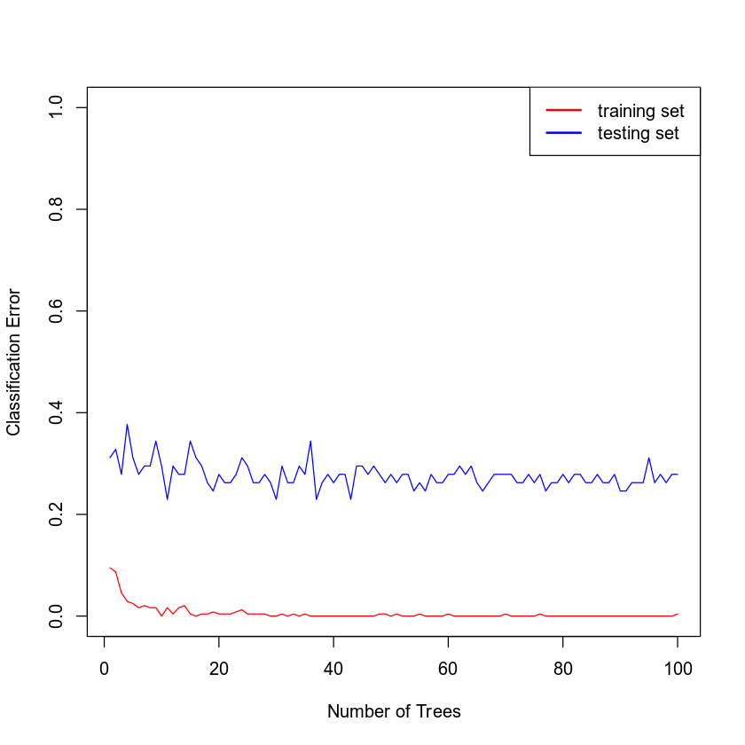

```r
set.seed(511038)
library(randomForest)

# checking
#=====================================================================
train = c()
test = c()
trees = c()

for(i in seq(from=1, to=100, by=1)) {
    #print(i)

    trees <- c(trees, i)

    model_rf3 <- randomForest(target ~ age + sex + cp + trestbps + chol + restecg + exang + slope + ca, data=train.data, ntree = i)

    train.data.predict <- predict(model_rf3, train.data, type = "class")
    conf.matrix1 <- table(train.data$target, train.data.predict)
    train_error = 1-(sum(diag(conf.matrix1)))/sum(conf.matrix1)
    train <- c(train, train_error)

    test.data.predict <- predict(model_rf3, test.data, type = "class")
    conf.matrix2 <- table(test.data$target, test.data.predict)
    test_error = 1-(sum(diag(conf.matrix2)))/sum(conf.matrix2)
    test <- c(test, test_error)
}

#matplot (trees, cbind (train, test), ylim=c(0,0.5) , type = c("l", "l"), lwd=2, col=c("red","blue"), ylab="Error", xlab="number of trees")
#legend('topright',legend = c('training set','testing set'), col = c("red","blue"), lwd = 2 )

plot(trees, train,type = "l",ylim=c(0,1.0),col = "red", xlab = "Number of Trees", ylab = "Classification Error")
lines(test, type = "l", col = "blue")
legend('topright',legend = c('training set','testing set'), col = c("red","blue"), lwd = 2 )
```

```r
predicted_target <- predict(model_rf2, test.data, type = "class")
predicted_target_df <- data.frame(predicted_target)
data <- cbind('actual target'=test.data$target, 'predicted target'=predicted_target_df)
print(data)
```

```
    actual target predicted_target
4               0                0
6               1                1
9               0                0
16              0                0
19              0                0
20              0                1
26              1                1
28              1                1
30              1                0
37              0                0
44              1                1
52              1                1
59              0                1
63              0                0
```

[output cut: 47 more lines]

## Random Forest Regression Model

You have been asked to create a random forest regression model for maximum heart rate achieved using the variables age *(age)*, sex *(sex)*, chest pain type *(cp)*, resting blood pressure *(trestbps)*, cholesterol measurement *(chol)*, resting electrocardiographic measurement *(restecg)*, exercise-induced angina *(exang)*, slope of peak exercise *(slope)*, and number of major vessels *(ca)*. Before writing any code, review Section 6 of the Summary Report template to see the questions you will be answering about your model.

Run your scripts to get the outputs of your analysis. Then use the outputs to answer the questions in your summary report.

**Note: Use the + (plus) button to add new code blocks, if needed.**

```r
set.seed(511038)

# Partition the data set into training and testing data
samp.size = floor(0.80*nrow(heart_data))

# Original set
print("Number of rows for the original set")
nrow(heart_data)

# Training set
print("Number of rows for the training set")
train_ind = sample(seq_len(nrow(heart_data)), size = samp.size)
train.data = heart_data[train_ind,]
nrow(train.data)

# Testing set
print("Number of rows for the testing set")
test.data = heart_data[-train_ind,]
nrow(test.data)
```

```
[1] "Number of rows for the original set"
```

303

```
[1] "Number of rows for the training set"
```

242

```
[1] "Number of rows for the testing set"
```

61

```r
set.seed(511038)
library(randomForest)
model_rf5 <- randomForest(thalach ~ age + sex + cp + trestbps + chol + restecg + exang + slope + ca, data=train.data, ntree = 80)


# Root mean squared error
RMSE = function(pred, obs) {
    return(sqrt( sum( (pred - obs)^2 )/length(pred) ) )
}

print("======================================================================================================================")
print('Root Mean Squared Error: TRAINING set based on random forest regression model built using 80 trees')
pred <- predict(model_rf5, newdata=train.data, type='response')
RMSE(pred, train.data$thalach)


print("======================================================================================================================")
print('Root Mean Squared Error: TESTING set based on random forest regression model built using 80 trees')
pred <- predict(model_rf5, newdata=test.data, type='response')
RMSE(pred, test.data$thalach)
```

```
[1] "======================================================================================================================"
[1] "Root Mean Squared Error: TRAINING set based on random forest regression model built using 80 trees"
```

9.66224345726083

```
[1] "======================================================================================================================"
[1] "Root Mean Squared Error: TESTING set based on random forest regression model built using 80 trees"
```

17.3058828751699

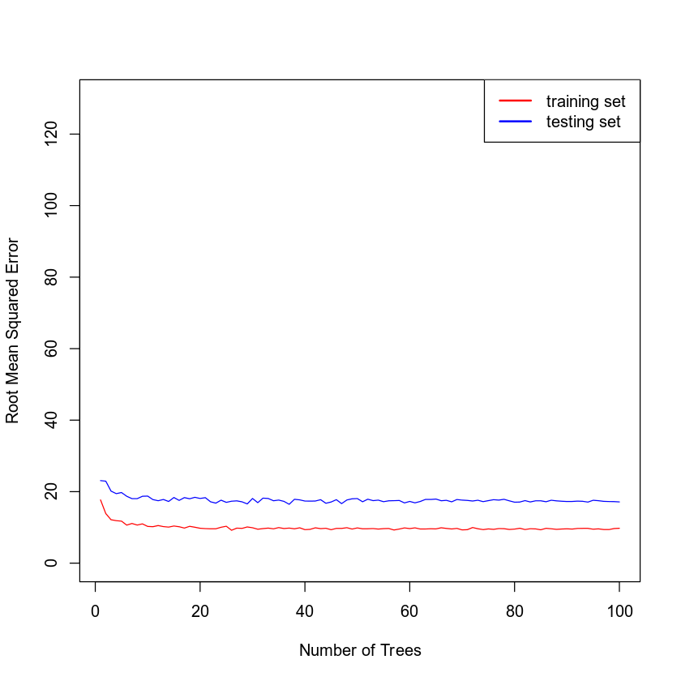

```r
set.seed(511038)
library(randomForest)

# Root mean squared error
RMSE = function(pred, obs) {
    return(sqrt( sum( (pred - obs)^2 )/length(pred) ) )
}


# checking
#=====================================================================
train = c()
test = c()
trees = c()

for(i in seq(from=1, to=100, by=1)) {
    trees <- c(trees, i)
    model_rf7 <- randomForest(thalach ~ age + sex + cp + trestbps + chol + restecg + exang + slope + ca, data=train.data, ntree = i)

    pred <- predict(model_rf7, newdata=train.data, type='response')
    rmse_train <-  RMSE(pred, train.data$thalach)
    train <- c(train, rmse_train)

    pred <- predict(model_rf7, newdata=test.data, type='response')
    rmse_test <-  RMSE(pred, test.data$thalach)
    test <- c(test, rmse_test)
}

plot(trees, train,type = "l",ylim=c(0,130),col = "red", xlab = "Number of Trees", ylab = "Root Mean Squared Error")
lines(test, type = "l", col = "blue")
legend('topright',legend = c('training set','testing set'), col = c("red","blue"), lwd = 2 )
```

```r
predicted_rate <- predict(model_rf5, newdata=test.data, type='response')
predicted_rate_df <- data.frame(predicted_rate)
data <- cbind('actual heart rate'=test.data$thalach, 'predicted heart rate'=predicted_rate_df)
print(data)
```

```
    actual heart rate predicted_rate
4                 144       146.6504
6                 172       149.5192
9                 134       142.2816
16                141       130.8961
19                112       132.1258
20                162       160.2646
26                115       145.7931
28                169       158.6281
30                161       136.9812
37                174       147.6088
44                133       153.1240
52                182       160.1305
59                158       158.8586
63                103       141.8244
```

[output cut: 47 more lines]

## End of Project Two Jupyter Notebook

The HTML output can be downloaded by clicking **File**, then **Download as**, then **HTML**. Be sure to answer all of the questions in the Summary Report template for Project Two, and to include your completed Jupyter Notebook scripts as part of your submission.